# AOL Data Mining and Visualization (DTSC6005001)

- ALyza Rahima Pramudya - 2502032125
- Faishal Kamil - 2502001063
- Shafa Amira Qonitatin - 2502009173

## About Dataset

Our dataset is from the following link: https://www.kaggle.com/datasets/kumarajarshi/life-expectancy-who and more details about the dataset are described below:

**Objective:** The problem at hand is to perform Exploratory Data Analysis (EDA) and also perform predictive modeling on the Life Expectancy dataset. By analyzing the dataset, we aim to gain insight into the factors that influence life expectancy and understand the patterns and relationships in the data.

**Problem Statement:** The objective of this task is to perform EDA on the Life Expectancy dataset that can provide meaningful insights and visualizations so that we can create predictive modeling to predict Life Expectancy. The analysis should aim to answer questions such as:

- Are there any outliers or missing values in the dataset that need to be addressed?
- Are there any significant differences in life expectancy across countries or regions?
- Are there any trends or patterns in life expectancy over time?
- What are the factors influencing life expectancy?
- Can a predictive model (Random Forest) be developed to accurately predict life expectancy?

**Data Description:** This dataset contains information about various factors that may affect the life expectancy of individuals in different countries. The dataset includes the following features:

- Country: Name of the country
- Year: Year of observation
- Status: Development status of the country (Developed or Developing)
- Life expectancy: Life expectancy in age
- Adult mortality: Probability of dying between 15 and 60 years per 1000 population
- Infant deaths: Number of infant deaths per 1000 population
- Alcohol: Alcohol consumption per capita (in liters of pure alcohol)
- Percentage expenditure: Expenditure on healthcare as a percentage of GDP per capita
- Hepatitis B: Hepatitis B immunization coverage among 1-year-olds (in percentage)
- Measles: Number of reported measles cases per 1000 population
- BMI: Average Body Mass Index (BMI) of the population
- Under-five deaths: Number of deaths under the age of five per 1000 population
- Polio: Polio immunization coverage among 1-year-olds (in percentage)
- Total expenditure: Total government expenditure on health as a percentage of GDP
- Diphtheria: Diphtheria immunization coverage among 1-year-olds (in percentage)
- HIV/AIDS: Deaths per 1000 live births caused by HIV/AIDS
- GDP: Gross Domestic Product per capita (in USD)
- Population: Population of the country
- Thinness 1-19 years: Prevalence of thinness among children and adolescents aged 10-19 (in percentage)
- Thinness 5-9 years: Prevalence of thinness among children aged 5-9 (in percentage)
- Income composition of resources: Human Development Index (HDI) of income composition of resources
- Schooling: Number of years of schooling

These features provide a wide range of variables that can be explored and analyzed to understand the factors influencing life expectancy.

## 1) Understanding all variables

In this section, we must first understand about each variable so that we understand more about the dataset we are analyzing.

First, we import libraries that we will need

```r
library(dplyr)
```

```r
library(ggplot2)
library(reshape2)
library(caTools)
library(randomForest)
```

Then, we load the dataset and put it into the variable `df`

```r
df = read.csv("~/pramudya/matkul/data mining/Life Expectancy Data.csv")
```

```r
head(df)
```

```
##       Country Year     Status Life.expectancy Adult.Mortality infant.deaths
## 1 Afghanistan 2015 Developing            65.0             263            62
## 2 Afghanistan 2014 Developing            59.9             271            64
## 3 Afghanistan 2013 Developing            59.9             268            66
## 4 Afghanistan 2012 Developing            59.5             272            69
## 5 Afghanistan 2011 Developing            59.2             275            71
## 6 Afghanistan 2010 Developing            58.8             279            74
##   Alcohol percentage.expenditure Hepatitis.B Measles  BMI under.five.deaths
## 1    0.01              71.279624          65    1154 19.1                83
## 2    0.01              73.523582          62     492 18.6                86
## 3    0.01              73.219243          64     430 18.1                89
## 4    0.01              78.184215          67    2787 17.6                93
## 5    0.01               7.097109          68    3013 17.2                97
## 6    0.01              79.679367          66    1989 16.7               102
##   Polio Total.expenditure Diphtheria HIV.AIDS       GDP Population
```

[output cut: 20 more lines]

From the above observation, we can see that this dataset is a periodic dataset, where for example in `Afghanistan` there are variable values (such as Status, Life.expectancy, Adult.Mortality, infant.deaths, and so on) that have different values every year

```r
str(df)
```

```
## 'data.frame':    2938 obs. of  22 variables:
##  $ Country                        : chr  "Afghanistan" "Afghanistan" "Afghanistan" "Afghanistan" ...
##  $ Year                           : int  2015 2014 2013 2012 2011 2010 2009 2008 2007 2006 ...
##  $ Status                         : chr  "Developing" "Developing" "Developing" "Developing" ...
##  $ Life.expectancy                : num  65 59.9 59.9 59.5 59.2 58.8 58.6 58.1 57.5 57.3 ...
##  $ Adult.Mortality                : int  263 271 268 272 275 279 281 287 295 295 ...
##  $ infant.deaths                  : int  62 64 66 69 71 74 77 80 82 84 ...
##  $ Alcohol                        : num  0.01 0.01 0.01 0.01 0.01 0.01 0.01 0.03 0.02 0.03 ...
##  $ percentage.expenditure         : num  71.3 73.5 73.2 78.2 7.1 ...
##  $ Hepatitis.B                    : int  65 62 64 67 68 66 63 64 63 64 ...
##  $ Measles                        : int  1154 492 430 2787 3013 1989 2861 1599 1141 1990 ...
##  $ BMI                            : num  19.1 18.6 18.1 17.6 17.2 16.7 16.2 15.7 15.2 14.7 ...
##  $ under.five.deaths              : int  83 86 89 93 97 102 106 110 113 116 ...
##  $ Polio                          : int  6 58 62 67 68 66 63 64 63 58 ...
##  $ Total.expenditure              : num  8.16 8.18 8.13 8.52 7.87 9.2 9.42 8.33 6.73 7.43 ...
##  $ Diphtheria                     : int  65 62 64 67 68 66 63 64 63 58 ...
##  $ HIV.AIDS                       : num  0.1 0.1 0.1 0.1 0.1 0.1 0.1 0.1 0.1 0.1 ...
##  $ GDP                            : num  584.3 612.7 631.7 670 63.5 ...
##  $ Population                     : num  33736494 327582 31731688 3696958 2978599 ...
##  $ thinness..1.19.years           : num  17.2 17.5 17.7 17.9 18.2 18.4 18.6 18.8 19 19.2 ...
##  $ thinness.5.9.years             : num  17.3 17.5 17.7 18 18.2 18.4 18.7 18.9 19.1 19.3 ...
##  $ Income.composition.of.resources: num  0.479 0.476 0.47 0.463 0.454 0.448 0.434 0.433 0.415 0.405 ...
##  $ Schooling                      : num  10.1 10 9.9 9.8 9.5 9.2 8.9 8.7 8.4 8.1 ...
```

```r
summary(df)
```

```
##    Country               Year         Status          Life.expectancy
##  Length:2938        Min.   :2000   Length:2938        Min.   :36.30
##  Class :character   1st Qu.:2004   Class :character   1st Qu.:63.10
##  Mode  :character   Median :2008   Mode  :character   Median :72.10
##                     Mean   :2008                      Mean   :69.22
##                     3rd Qu.:2012                      3rd Qu.:75.70
##                     Max.   :2015                      Max.   :89.00
##                                                       NA's   :10
##  Adult.Mortality infant.deaths       Alcohol        percentage.expenditure
##  Min.   :  1.0   Min.   :   0.0   Min.   : 0.0100   Min.   :    0.000
##  1st Qu.: 74.0   1st Qu.:   0.0   1st Qu.: 0.8775   1st Qu.:    4.685
##  Median :144.0   Median :   3.0   Median : 3.7550   Median :   64.913
##  Mean   :164.8   Mean   :  30.3   Mean   : 4.6029   Mean   :  738.251
##  3rd Qu.:228.0   3rd Qu.:  22.0   3rd Qu.: 7.7025   3rd Qu.:  441.534
##  Max.   :723.0   Max.   :1800.0   Max.   :17.8700   Max.   :19479.912
##  NA's   :10                       NA's   :194
##   Hepatitis.B       Measles              BMI        under.five.deaths
##  Min.   : 1.00   Min.   :     0.0   Min.   : 1.00   Min.   :   0.00
##  1st Qu.:77.00   1st Qu.:     0.0   1st Qu.:19.30   1st Qu.:   0.00
##  Median :92.00   Median :    17.0   Median :43.50   Median :   4.00
##  Mean   :80.94   Mean   :  2419.6   Mean   :38.32   Mean   :  42.04
##  3rd Qu.:97.00   3rd Qu.:   360.2   3rd Qu.:56.20   3rd Qu.:  28.00
##  Max.   :99.00   Max.   :212183.0   Max.   :87.30   Max.   :2500.00
##  NA's   :553                        NA's   :34
##      Polio       Total.expenditure   Diphtheria       HIV.AIDS
##  Min.   : 3.00   Min.   : 0.370    Min.   : 2.00   Min.   : 0.100
##  1st Qu.:78.00   1st Qu.: 4.260    1st Qu.:78.00   1st Qu.: 0.100
##  Median :93.00   Median : 5.755    Median :93.00   Median : 0.100
##  Mean   :82.55   Mean   : 5.938    Mean   :82.32   Mean   : 1.742
##  3rd Qu.:97.00   3rd Qu.: 7.492    3rd Qu.:97.00   3rd Qu.: 0.800
##  Max.   :99.00   Max.   :17.600    Max.   :99.00   Max.   :50.600
##  NA's   :19      NA's   :226       NA's   :19
##       GDP              Population        thinness..1.19.years
##  Min.   :     1.68   Min.   :3.400e+01   Min.   : 0.10
##  1st Qu.:   463.94   1st Qu.:1.958e+05   1st Qu.: 1.60
##  Median :  1766.95   Median :1.387e+06   Median : 3.30
##  Mean   :  7483.16   Mean   :1.275e+07   Mean   : 4.84
##  3rd Qu.:  5910.81   3rd Qu.:7.420e+06   3rd Qu.: 7.20
##  Max.   :119172.74   Max.   :1.294e+09   Max.   :27.70
##  NA's   :448         NA's   :652         NA's   :34
##  thinness.5.9.years Income.composition.of.resources   Schooling
##  Min.   : 0.10      Min.   :0.0000                  Min.   : 0.00
##  1st Qu.: 1.50      1st Qu.:0.4930                  1st Qu.:10.10
##  Median : 3.30      Median :0.6770                  Median :12.30
##  Mean   : 4.87      Mean   :0.6276                  Mean   :11.99
##  3rd Qu.: 7.20      3rd Qu.:0.7790                  3rd Qu.:14.30
##  Max.   :28.60      Max.   :0.9480                  Max.   :20.70
##  NA's   :34         NA's   :167                     NA's   :163
```

In accordance with the previous explanation, where we all know that `Country` and `Status` are categorical variables so that when we run `summary()` it cannot display statistical information such as Min, 1st Qu, Median, Mean, 3rd Qu, and Max values so that the output is only the length, class, and mode, which the data size is 2938 and the data type is character.

From the observation, we can see that there are null values in 14 variables out of 22 variables in the dataset, especially in numerical variables, namely in the variables Life.expectancy, Adult.Mortality, Alcohol, Hepatitis.B, BMI, Polio, Total.expenditure, Diphtheria, GDP, Population, thinness.1.19.years, thinness.5.9.years, Income.composition.of.resources, Schooling which we will handle in section `2) Data Cleaning`.

## 2) Data Cleaning

```r
# counts the number of null values in each column
null_counts <- colSums(is.na(df))

# sort null_counts in descending order
sorted_null_counts <- sort(null_counts, decreasing = TRUE)

# display the sort result
sorted_null_counts
```

```
##                      Population                     Hepatitis.B
##                             652                             553
##                             GDP               Total.expenditure
##                             448                             226
##                         Alcohol Income.composition.of.resources
##                             194                             167
##                       Schooling                             BMI
##                             163                              34
##            thinness..1.19.years              thinness.5.9.years
##                              34                              34
##                           Polio                      Diphtheria
##                              19                              19
##                 Life.expectancy                 Adult.Mortality
##                              10                              10
##                         Country                            Year
##                               0                               0
##                          Status                   infant.deaths
##                               0                               0
##          percentage.expenditure                         Measles
##                               0                               0
##               under.five.deaths                        HIV.AIDS
##                               0                               0
```

In the null values detection above (which is actually the same as NAs’ in the `summary` function), we sort where the variables that have the highest null-values are Population, Hepatitis.B, and GDP, then the next step we will handle the null-values.

Now, we plot the number of null values in each variables.

```r
sorted_null_counts_df <- data.frame(variables = names(sorted_null_counts), counts = sorted_null_counts)
```

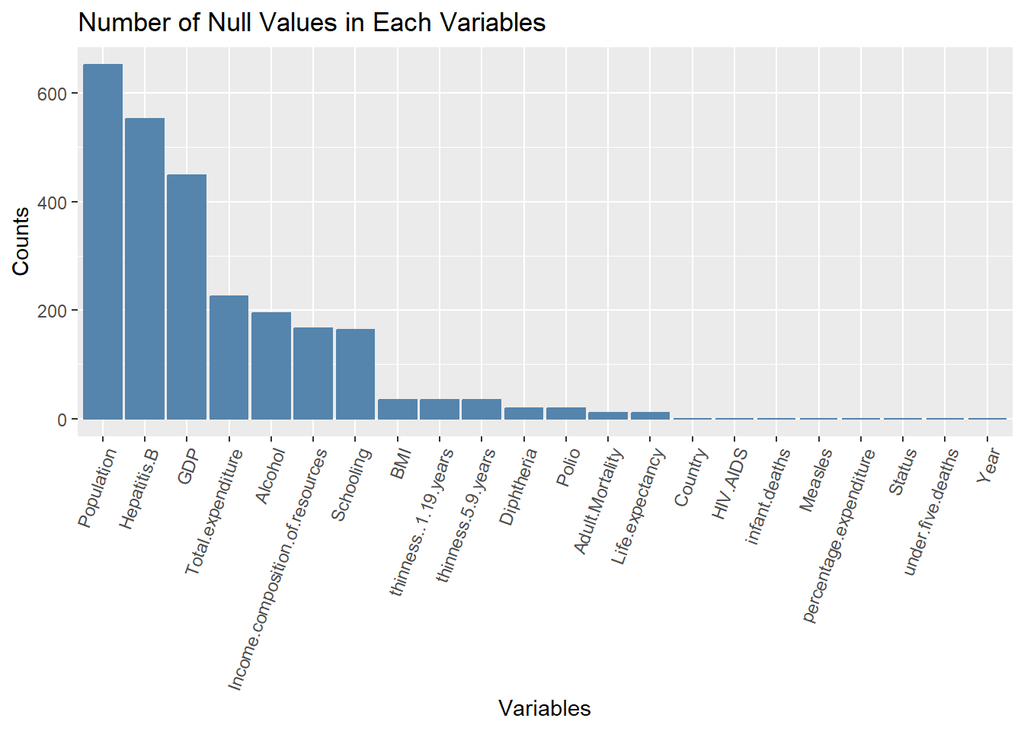

```r
ggplot(data = sorted_null_counts_df, aes(x = reorder(variables, desc(counts)), y = counts)) +
  geom_bar(stat = "identity", fill = "#5584AC", color = "#5584AC") +
  labs(x = "Variables", y = "Counts", title = "Number of Null Values in Each Variables") +
  theme(axis.text.x = element_text(angle = 70, hjust = 1))
```

```r
# calculate means of all the numeric variables
df_num = df[, c("Year","Life.expectancy", "Adult.Mortality", "infant.deaths", "Alcohol", "percentage.expenditure", "Hepatitis.B", "Polio","Measles", "BMI", "under.five.deaths", "Total.expenditure", "Diphtheria", "HIV.AIDS", "GDP", "Population", "thinness..1.19.years", "thinness.5.9.years", "Income.composition.of.resources", "Schooling")]

# calculate column means, excluding NA values
means <- colMeans(df_num, na.rm = TRUE)
means
```

```
##                            Year                 Life.expectancy
##                    2.007519e+03                    6.922493e+01
##                 Adult.Mortality                   infant.deaths
##                    1.647964e+02                    3.030395e+01
##                         Alcohol          percentage.expenditure
##                    4.602861e+00                    7.382513e+02
##                     Hepatitis.B                           Polio
##                    8.094046e+01                    8.255019e+01
##                         Measles                             BMI
##                    2.419592e+03                    3.832125e+01
##               under.five.deaths               Total.expenditure
##                    4.203574e+01                    5.938190e+00
##                      Diphtheria                        HIV.AIDS
##                    8.232408e+01                    1.742103e+00
##                             GDP                      Population
##                    7.483158e+03                    1.275338e+07
##            thinness..1.19.years              thinness.5.9.years
##                    4.839704e+00                    4.870317e+00
## Income.composition.of.resources                       Schooling
##                    6.275511e-01                    1.199279e+01
```

In the above step, we include all numeric variables. Why not just variables that have null values? because this `df_num` will be scaled and used in section `4.) Predictive Modeling`. Before we impute NA values, we calculate the column means first, excluding NA values.

```r
# impute NA values with column means
for(i in names(df_num)) {
  df_num[is.na(df_num[, i]), i] <- means[i]
}

# assign the imputed values back to the original dataframe
df[, names(df_num)] <- df_num

# check for remaining NA values
colSums(is.na(df))
```

```
##                         Country                            Year
##                               0                               0
##                          Status                 Life.expectancy
##                               0                               0
##                 Adult.Mortality                   infant.deaths
##                               0                               0
##                         Alcohol          percentage.expenditure
##                               0                               0
##                     Hepatitis.B                         Measles
##                               0                               0
##                             BMI               under.five.deaths
##                               0                               0
##                           Polio               Total.expenditure
##                               0                               0
##                      Diphtheria                        HIV.AIDS
##                               0                               0
##                             GDP                      Population
##                               0                               0
##            thinness..1.19.years              thinness.5.9.years
##                               0                               0
## Income.composition.of.resources                       Schooling
##                               0                               0
```

From the above code, we are looping to impute the NA value with its column average and setting the imputed value back to `df`. Since we will use it in section `3) Analyzing and Visualization`, if we do the visualization before we handle the missing values, it may lead to misinterpretation of the pattern and there is also a warning if we do it anyway. So, make sure we have to handle the null values before we do the visualization so that this will ensure that subsequent insights and conclusions are based on the most accurate and complete data possible.

And also why don’t we do the visualization after the data is completely clean or in other words, where the data has already been scaled? This will change the scale so we decided to only handle the null values before doing the visualization so that the results are also not too much manipulated so that it can produce a more accurate visualization.

```r
# factorize categorical variables
df$Status <- as.factor(df$Status)
df$Country <- as.factor(df$Country)
```

We factorize categorical variables because it can provides a way to convert them into a suitable numeric representation, enabling statistical analysis, predictive modeling, and effective visualization of categorical data.

```r
Max <- apply(df_num, 2, max)
Min <- apply(df_num, 2, min)

scaled <- as.data.frame(scale(df_num, center = Min, scale = Max - Min))
head(scaled)
```

```
##        Year Life.expectancy Adult.Mortality infant.deaths Alcohol
## 1 1.0000000       0.5445920       0.3628809    0.03444444       0
## 2 0.9333333       0.4478178       0.3739612    0.03555556       0
## 3 0.8666667       0.4478178       0.3698061    0.03666667       0
## 4 0.8000000       0.4402277       0.3753463    0.03833333       0
## 5 0.7333333       0.4345351       0.3795014    0.03944444       0
## 6 0.6666667       0.4269450       0.3850416    0.04111111       0
##   percentage.expenditure Hepatitis.B     Polio     Measles       BMI
## 1           0.0036591349   0.6530612 0.0312500 0.005438701 0.2097335
## 2           0.0037743283   0.6224490 0.5729167 0.002318753 0.2039397
## 3           0.0037587051   0.6428571 0.6145833 0.002026553 0.1981460
## 4           0.0040135816   0.6734694 0.6666667 0.013134888 0.1923523
## 5           0.0003643296   0.6836735 0.6770833 0.014200007 0.1877173
## 6           0.0040903352   0.6632653 0.6562500 0.009373984 0.1819235
##   under.five.deaths Total.expenditure Diphtheria HIV.AIDS          GDP
```

[output cut: 20 more lines]

Now, we also scaled our dataset so it can have the similar units for each variables and we put in at `scaled`. Then, we combine the categorical variables and numerical variables and we put to `df_clean` that we will use in section `4.) Predictive Modeling`

```r
df_clean <- df %>%
  mutate(across(where(is.numeric), ~ scaled[[cur_column()]]))

head(df_clean)
```

```
##       Country      Year     Status Life.expectancy Adult.Mortality
## 1 Afghanistan 1.0000000 Developing       0.5445920       0.3628809
## 2 Afghanistan 0.9333333 Developing       0.4478178       0.3739612
## 3 Afghanistan 0.8666667 Developing       0.4478178       0.3698061
## 4 Afghanistan 0.8000000 Developing       0.4402277       0.3753463
## 5 Afghanistan 0.7333333 Developing       0.4345351       0.3795014
## 6 Afghanistan 0.6666667 Developing       0.4269450       0.3850416
##   infant.deaths Alcohol percentage.expenditure Hepatitis.B     Measles
## 1    0.03444444       0           0.0036591349   0.6530612 0.005438701
## 2    0.03555556       0           0.0037743283   0.6224490 0.002318753
## 3    0.03666667       0           0.0037587051   0.6428571 0.002026553
## 4    0.03833333       0           0.0040135816   0.6734694 0.013134888
## 5    0.03944444       0           0.0003643296   0.6836735 0.014200007
## 6    0.04111111       0           0.0040903352   0.6632653 0.009373984
##         BMI under.five.deaths     Polio Total.expenditure Diphtheria HIV.AIDS
```

[output cut: 20 more lines]

We also have to encode our categorical variable, which `Status` variable

```r
# encode the categorical variable
df_clean$Status <- ifelse(df_clean$Status == "Developed", 1, 0)
```

And also change our categorical variable, which `Country` variable to numerical

```r
df_clean$Country <- as.numeric(df_clean$Country)
```

```r
head(df_clean)
```

```
##   Country      Year Status Life.expectancy Adult.Mortality infant.deaths
## 1       1 1.0000000      0       0.5445920       0.3628809    0.03444444
## 2       1 0.9333333      0       0.4478178       0.3739612    0.03555556
## 3       1 0.8666667      0       0.4478178       0.3698061    0.03666667
## 4       1 0.8000000      0       0.4402277       0.3753463    0.03833333
## 5       1 0.7333333      0       0.4345351       0.3795014    0.03944444
## 6       1 0.6666667      0       0.4269450       0.3850416    0.04111111
##   Alcohol percentage.expenditure Hepatitis.B     Measles       BMI
## 1       0           0.0036591349   0.6530612 0.005438701 0.2097335
## 2       0           0.0037743283   0.6224490 0.002318753 0.2039397
## 3       0           0.0037587051   0.6428571 0.002026553 0.1981460
## 4       0           0.0040135816   0.6734694 0.013134888 0.1923523
## 5       0           0.0003643296   0.6836735 0.014200007 0.1877173
## 6       0           0.0040903352   0.6632653 0.009373984 0.1819235
##   under.five.deaths     Polio Total.expenditure Diphtheria HIV.AIDS
```

[output cut: 20 more lines]

## 3) Analyzing and Visualization

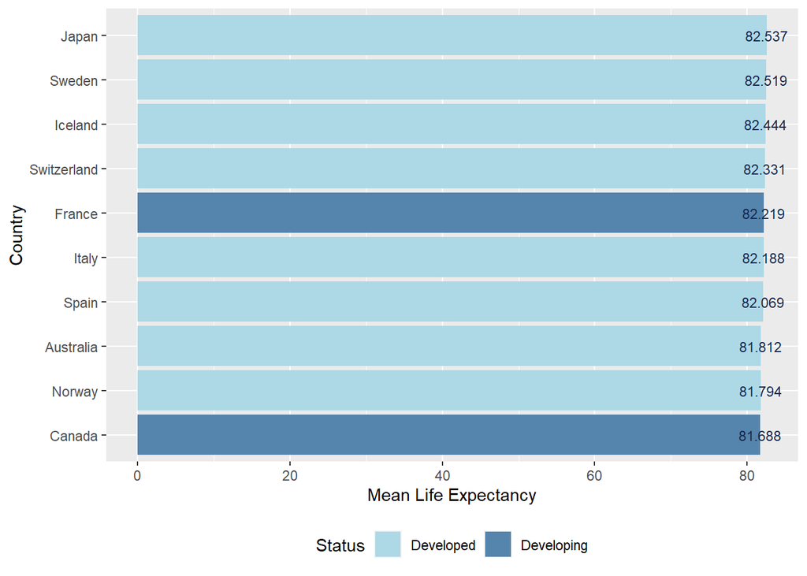

```r
mean_countries <- df %>%
  group_by(Country) %>%
  summarise(mean_life_expectancy = mean(Life.expectancy), status = unique(Status)) %>%
  arrange(desc(mean_life_expectancy))

top_10_countries <- head(mean_countries, 10)

ggplot(top_10_countries, aes(x = reorder(Country, mean_life_expectancy), y = mean_life_expectancy, fill = status)) +
  geom_bar(stat = "identity") +
  geom_text(aes(label = round(mean_life_expectancy, 3)), size = 3, color = "#142850") +
  labs(x = "Country", y = "Mean Life Expectancy", fill = "Status") +
  coord_flip() +
  scale_fill_manual(values = c("lightblue", "#5584AC"), labels = c("Developed", "Developing")) +
  theme(legend.position = "bottom")
```

From 2000-2015 Japan has the highest Life Expectancy accross the other countries and from the top 10 countries with the highest mean more are from developed countries compared to developing countries. This can be validated using the Point Biserial Correlation.

```r
cor.test(df_clean$Status, df_clean$Life.expectancy)
```

```
##
##  Pearson's product-moment correlation
##
## data:  df_clean$Status and df_clean$Life.expectancy
## t = 29.805, df = 2936, p-value < 2.2e-16
## alternative hypothesis: true correlation is not equal to 0
## 95 percent confidence interval:
##  0.4537077 0.5092489
## sample estimates:
##       cor
## 0.4819623
```

Based on this output, it can be concluded that there is a significant positive correlation between the variables “Status” and “Life.expectancy”. Thus, status has a corresponding influence on life expectancy.

Now, we want to see if Year has a correlation with Life Expectancy Rate

```r
grouped_data <- df %>%
  group_by(Country) %>%
  select(Country, Year, Life.expectancy)

head(grouped_data,50)
```

```
## # A tibble: 50 × 3
## # Groups:   Country [4]
##    Country      Year Life.expectancy
##    <fct>       <int>           <dbl>
##  1 Afghanistan  2015            65
##  2 Afghanistan  2014            59.9
##  3 Afghanistan  2013            59.9
##  4 Afghanistan  2012            59.5
##  5 Afghanistan  2011            59.2
##  6 Afghanistan  2010            58.8
##  7 Afghanistan  2009            58.6
##  8 Afghanistan  2008            58.1
##  9 Afghanistan  2007            57.5
## 10 Afghanistan  2006            57.3
## # … with 40 more rows
```

From the output above, it can be seen at a glance that in Country Afgahnistan there is an increase in the percentage of Life expectancy and likewise for Albania. To validate this argument, we conducted a Linear Regression to see the correlation between Year and Life Expectancy.

```r
reg_model <- lm(Life.expectancy ~ Year, data = df)
summary(reg_model)
```

```
##
## Call:
## lm(formula = Life.expectancy ~ Year, data = df)
##
## Residuals:
##     Min      1Q  Median      3Q     Max
## -33.792  -6.442   2.833   6.258  21.005
##
## Coefficients:
##               Estimate Std. Error t value Pr(>|t|)
## (Intercept) -632.47819   75.24081  -8.406   <2e-16 ***
## Year           0.34954    0.03748   9.326   <2e-16 ***
## ---
## Signif. codes:  0 '***' 0.001 '**' 0.01 '*' 0.05 '.' 0.1 ' ' 1
##
## Residual standard error: 9.371 on 2936 degrees of freedom
## Multiple R-squared:  0.02877,    Adjusted R-squared:  0.02844
## F-statistic: 86.98 on 1 and 2936 DF,  p-value: < 2.2e-16
```

As per the output, we can see that the variables “Year” and “Life.expectancy” have a significant correlation, and the variable “Year” significantly affects the variable “Life.expectancy”. This can be interpreted from the p-value given in the output, which is “<2e-16”, which means it is far below the significance level of 0.05. In addition, we can also see the regression coefficient for the variable “Year” which is 0.34954. This coefficient indicates that every one unit increase in the “Year” variable (i.e., one year), is expected to increase the life expectancy value by 0.34954.

Now, we want to know what are the factors that affect Life Expectancy? The first step, because we want to calculate the correlation using Pearson Correlation, the variable must be numeric type

```r
df_clean_num <- df_clean[, sapply(df_clean, is.numeric)]
```

```r
df_clean_num <- subset(df_clean_num, select = -c(Year))
```

Next, we will perform calculations to find the correlation value for each variable as in the beginning using the cor() function.

```r
cor_matrix <- cor(df_clean_num)
print(cor_matrix)
```

```
##                                      Country      Status Life.expectancy
## Country                          1.000000000  0.03240054     -0.01563461
## Status                           0.032400544  1.00000000      0.48196234
## Life.expectancy                 -0.015634610  0.48196234      1.00000000
## Adult.Mortality                  0.038669423 -0.31517071     -0.69635931
## infant.deaths                   -0.030728891 -0.11225158     -0.19653500
## Alcohol                         -0.059389598  0.57937142      0.39159834
## percentage.expenditure          -0.032862782  0.45426097      0.38179117
## Hepatitis.B                     -0.018430821  0.09564164      0.20377144
## Measles                         -0.024650742 -0.07695507     -0.15757382
## BMI                              0.018333187  0.31087258      0.55925530
## under.five.deaths               -0.026717839 -0.11519509     -0.22250302
## Polio                            0.018274813  0.22009846      0.46157378
## Total.expenditure                0.053403933  0.28998505      0.20798062
## Diphtheria                      -0.005669522  0.21676347      0.47541838
## HIV.AIDS                         0.089856187 -0.14859006     -0.55645682
## GDP                             -0.015174070  0.44591112      0.43049302
## Population                      -0.014390140 -0.04109085     -0.01963770
## thinness..1.19.years             0.007571854 -0.36793398     -0.47216188
## thinness.5.9.years               0.022108888 -0.36629714     -0.46662921
## Income.composition.of.resources -0.023371997  0.45730174      0.69248280
## Schooling                       -0.025035491  0.49144366      0.71506634
##                                 Adult.Mortality infant.deaths     Alcohol
## Country                              0.03866942   -0.03072889 -0.05938960
## Status                              -0.31517071   -0.11225158  0.57937142
## Life.expectancy                     -0.69635931   -0.19653500  0.39159834
## Adult.Mortality                      1.00000000    0.07874713 -0.19040781
## infant.deaths                        0.07874713    1.00000000 -0.11381227
## Alcohol                             -0.19040781   -0.11381227  1.00000000
## percentage.expenditure              -0.24281353   -0.08561222  0.33963429
## Hepatitis.B                         -0.13859091   -0.17878339  0.07544715
## Measles                              0.03117404    0.50112834 -0.05105499
## BMI                                 -0.38144941   -0.22721997  0.31807030
## under.five.deaths                    0.09413509    0.99662888 -0.11077713
## Polio                               -0.27269358   -0.17067376  0.21374404
## Total.expenditure                   -0.11087454   -0.12656412  0.29489812
## Diphtheria                          -0.27301389   -0.17515631  0.21524194
## HIV.AIDS                             0.52372692    0.02523132 -0.04864971
## GDP                                 -0.27705292   -0.10710904  0.31859116
## Population                          -0.01250145    0.54852167 -0.03076466
```

[output cut: 121 more lines]

```
## percentage.expenditure                              0.380373551  0.38810498
## Hepatitis.B                                         0.150992044  0.17175483
## Measles                                            -0.115764074 -0.12260854
## BMI                                                 0.479837369  0.50810548
## under.five.deaths                                  -0.161533413 -0.20711142
## Polio                                               0.355397638  0.38583163
## Total.expenditure                                   0.149094726  0.21831013
## Diphtheria                                          0.371729147  0.38994380
## HIV.AIDS                                           -0.247453534 -0.21861975
## GDP                                                 0.440317075  0.42948916
## Population                                         -0.007951445 -0.02946490
## thinness..1.19.years                               -0.406661733 -0.44614009
## thinness.5.9.years                                 -0.395778501 -0.43577723
## Income.composition.of.resources                     1.000000000  0.79620705
## Schooling                                           0.796207053  1.00000000
```

Then we will do melting or convert the correlation matrix format into a long format using the reshape2 library so that it will produce a data frame with three columns, namely Var1, Var2, and value, where Var1 and Var2 represent the column names in the converted correlation matrix and value is the correlation value between Var1 and Var2. After that, we can confirm by using the head() function.

```r
corr_melted <- melt(cor(df_clean_num))
head(corr_melted)
```

```
##              Var1    Var2       value
## 1         Country Country  1.00000000
## 2          Status Country  0.03240054
## 3 Life.expectancy Country -0.01563461
## 4 Adult.Mortality Country  0.03866942
## 5   infant.deaths Country -0.03072889
## 6         Alcohol Country -0.05938960
```

Now, we sort the data to see what variable has the highest correlation value with Life Expectancy

```r
corr_mat <- cor(df_clean_num)[,"Life.expectancy"]
corr_mat <- sort(corr_mat, decreasing = TRUE)

head(as.data.frame(corr_mat), 10)
```

```
##                                  corr_mat
## Life.expectancy                 1.0000000
## Schooling                       0.7150663
## Income.composition.of.resources 0.6924828
## BMI                             0.5592553
## Status                          0.4819623
## Diphtheria                      0.4754184
## Polio                           0.4615738
## GDP                             0.4304930
## Alcohol                         0.3915983
## percentage.expenditure          0.3817912
```

The correlation coefficient between “Life.expectancy” and “Schooling” is 0.7150663, indicating a strong positive correlation. This suggests that higher levels of schooling are associated with increased life expectancy.The correlation coefficient between “Life.expectancy” and “Income.composition.of.resources” is 0.6924828, indicating a strong positive correlation. This suggests that higher levels of income composition of resources are associated with increased life expectancy and so on.

Now, we plot using heatmap to visualize the correlation values between the variable “Life.expectancy” and other variables

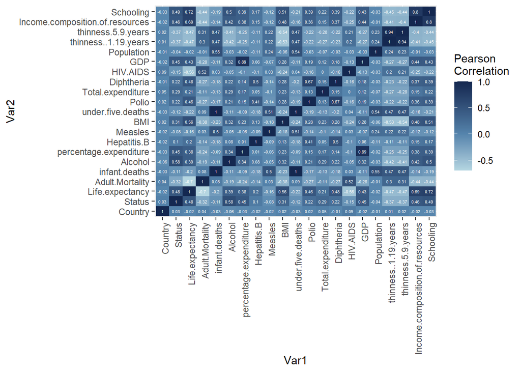

```r
corr_mat <- cor(df_clean_num)

corr_melted <- melt(corr_mat)

ggplot(corr_melted, aes(x = Var1, y = Var2, fill = value, label = round(value, 2))) +
  geom_tile() +
  geom_text(color = "white", size = 1.5) +
  scale_fill_gradient2(low = "#DEFCF9", mid = "#5584AC", high = "#142850",
                       name = "Pearson\nCorrelation") +
  theme(axis.text.x = element_text(angle = 90, vjust = 0.8, hjust = 1))
```

## 4) Predictive Modelling

First step that we have to do is split our dataset. We will split df_clean with a split ratio of 80%:20%, where the train dataset is 80% of the total data in df_clean and the test dataset is the remaining 20% of the df_clean data.

```r
split = sample.split(df_clean$Life.expectancy, SplitRatio = 0.80)

train <- subset(df_clean, split == TRUE)
test <- subset(df_clean, split == FALSE)
```

Next, we create a formula for what columns will be fit to the model so that they are not written one by one. Where in this formula the dependent variable is Life.Expectancy and the independent variables are variables other than Life.Expectancy or we can see the output below:

```r
n <- names(train)
n
```

```
##  [1] "Country"                         "Year"
##  [3] "Status"                          "Life.expectancy"
##  [5] "Adult.Mortality"                 "infant.deaths"
##  [7] "Alcohol"                         "percentage.expenditure"
##  [9] "Hepatitis.B"                     "Measles"
## [11] "BMI"                             "under.five.deaths"
## [13] "Polio"                           "Total.expenditure"
## [15] "Diphtheria"                      "HIV.AIDS"
## [17] "GDP"                             "Population"
## [19] "thinness..1.19.years"            "thinness.5.9.years"
## [21] "Income.composition.of.resources" "Schooling"
```

```r
f <- as.formula(paste("Life.expectancy ~", paste(n[!n %in% "Life.expectancy"], collapse = " + ")))
f
```

```
## Life.expectancy ~ Country + Year + Status + Adult.Mortality +
##     infant.deaths + Alcohol + percentage.expenditure + Hepatitis.B +
##     Measles + BMI + under.five.deaths + Polio + Total.expenditure +
##     Diphtheria + HIV.AIDS + GDP + Population + thinness..1.19.years +
##     thinness.5.9.years + Income.composition.of.resources + Schooling
```

Loads the randomForest library into R and creates a random forest model using the randomForest() function, where the parameters are the formula above and the data to be trained.

```r
modelRF <- randomForest(f,data=train)
print(modelRF)
```

```
##
## Call:
##  randomForest(formula = f, data = train)
##                Type of random forest: regression
##                      Number of trees: 500
## No. of variables tried at each split: 7
##
##           Mean of squared residuals: 0.001192323
##                     % Var explained: 96.39
```

Next, we will predict our model using the test dataset and store it in the predictedRF variable. Then, we will combine the predictedRF and `test$Life.expectancy` columns into one data frame, where predictedRF contains the predicted value generated by the model, while `test$Life.expectancy` contains the actual value of the response variable. Then we will name it “Predicted Value” for the prediction and “Ground Truth” for the actual value.

```r
predictedRF <- predict(modelRF,test)
resultsRF <- cbind(predictedRF,test$Life.expectancy)
colnames(resultsRF) <- c('Predicted Value','Ground Truth')
resultsRF <- as.data.frame(resultsRF)
resultsRF
```

```
##      Predicted Value Ground Truth
## 4          0.4479665    0.4402277
## 8          0.4165720    0.4136622
## 11         0.3979781    0.3984820
## 18         0.7669658    0.7817837
## 19         0.7683468    0.7760911
## 25         0.7244426    0.7514231
## 39         0.7130460    0.7229602
## 43         0.6768801    0.6944972
## 45         0.6913397    0.6717268
## 50         0.3317758    0.2922201
## 63         0.2712862    0.1783681
## 75         0.7073627    0.7267552
## 82         0.7606436    0.7571157
## 91         0.7398399    0.7324478
```

[output cut: 575 more lines]

Next, we will plot between the predicted value (x-axis) and the ground truth (y-axis) using a scatter plot

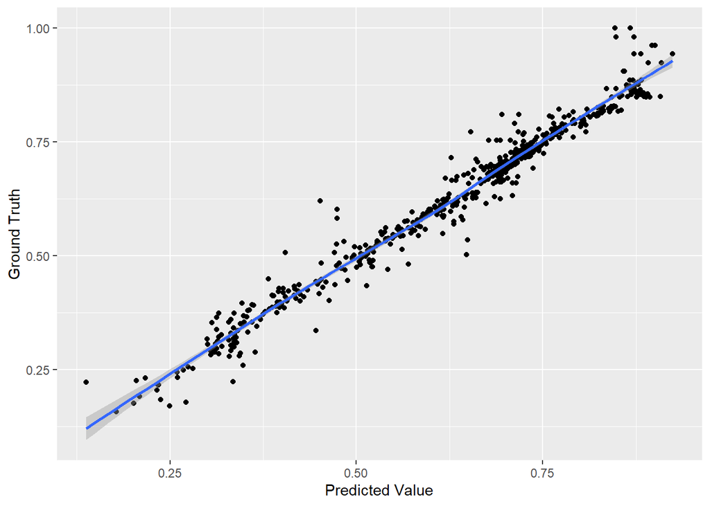

```r
#create a scatter plot between the predicted value (x-axis) and the true value (y-axis)
plotRF <- ggplot(resultsRF,aes(x=resultsRF$`Predicted Value`,y=resultsRF$`Ground Truth`)) + geom_point() + stat_smooth() + xlab("Predicted Value") + ylab("Ground Truth")
plotRF
```

From the plot, we can see the distribution of data on the predicted value and ground truth and the line from our random forest model. It can be seen that the distribution of the points is close to the trend line (blue line) so this can be an indication of the good performance of the random forest model in predicting the target value.

A linear pattern like the output above can also be assumed that there is a significant correlation between the predicted value and the ground truth and the random forest model has good performance.

This can also be proven by calculating the Mean Square Error with the code below

```r
#calculate Mean Squared Error
MSE_RF <- sum((resultsRF$`Predicted Value` - resultsRF$`Ground Truth`)^2)/nrow(test)
MSE_RF
```

```
## [1] 0.0009873076
```

Importance() function will calculate the importance score of independent variables in our model, this score measures how often each variable is used in the formation of decisions by each variable

```r
# importance of each predictor
importance(modelRF)
```

```
##                                 IncNodePurity
## Country                             0.4684686
## Year                                0.5714447
## Status                              0.7125337
## Adult.Mortality                    14.5783898
## infant.deaths                       1.1734400
## Alcohol                             0.8005974
## percentage.expenditure              0.4157968
## Hepatitis.B                         0.2754716
## Measles                             0.2921485
## BMI                                 2.7521370
## under.five.deaths                   2.9409179
## Polio                               1.1078431
## Total.expenditure                   0.5047897
## Diphtheria                          1.4368726
## HIV.AIDS                           23.0675429
## GDP                                 0.5239677
## Population                          0.2785400
## thinness..1.19.years                1.3563796
## thinness.5.9.years                  1.8704883
## Income.composition.of.resources    15.5195865
## Schooling                           6.6313758
```

In this context, the higher the “IncNodePurity” value of a feature, the more important it is in explaining variations in the data and influencing the prediction results. Features with higher “IncNodePurity” values are considered to have a greater contribution to the model. We can see from the output above, where the variables with thw highest “IncNodePurity” is HIV.AIDS

To make it easier to see, we plot our modelRF using VarImPlot function()

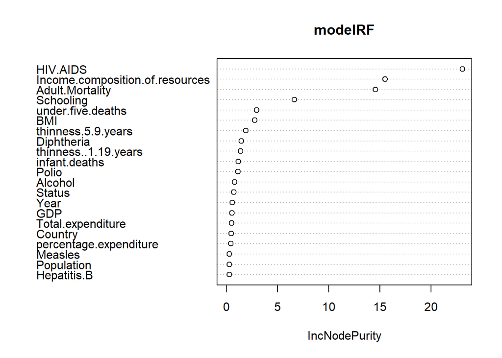

```r
varImpPlot(modelRF)
```